# Week 10 Day 2 Homework

# Load in libraries

```r
library(tidyverse)
library(janitor)
library(mosaic)
library(GGally)
```

# MVP

## 1.

Load the housing_prices.csv data set and undertake an initial exploration of the data. You will find details on the data set on the relevant Kaggle page

```r
housing_prices <- read_csv(here::here("data/housing_prices.csv"))
```

```r
head(housing_prices, 5)
```

| longitude | latitude | housing_median_age | total_rooms | total_bedrooms | population | households | median_income | median_house_value | ocean_proximity |
| --- | --- | --- | --- | --- | --- | --- | --- | --- | --- |
| -122.23 | 37.88 | 41 | 880 | 129 | 322 | 126 | 8.3252 | 452600 | NEAR BAY |
| -122.22 | 37.86 | 21 | 7099 | 1106 | 2401 | 1138 | 8.3014 | 358500 | NEAR BAY |
| -122.24 | 37.85 | 52 | 1467 | 190 | 496 | 177 | 7.2574 | 352100 | NEAR BAY |
| -122.25 | 37.85 | 52 | 1274 | 235 | 558 | 219 | 5.6431 | 341300 | NEAR BAY |
| -122.25 | 37.85 | 52 | 1627 | 280 | 565 | 259 | 3.8462 | 342200 | NEAR BAY |

```r
glimpse(housing_prices)
```

```
Rows: 19,675
Columns: 10
$ longitude          <dbl> -122.23, -122.22, -122.24, -122.25,…
$ latitude           <dbl> 37.88, 37.86, 37.85, 37.85, 37.85, …
$ housing_median_age <dbl> 41, 21, 52, 52, 52, 52, 52, 52, 42,…
$ total_rooms        <dbl> 880, 7099, 1467, 1274, 1627, 919, 2…
$ total_bedrooms     <dbl> 129, 1106, 190, 235, 280, 213, 489,…
$ population         <dbl> 322, 2401, 496, 558, 565, 413, 1094…
$ households         <dbl> 126, 1138, 177, 219, 259, 193, 514,…
$ median_income      <dbl> 8.3252, 8.3014, 7.2574, 5.6431, 3.8…
$ median_house_value <dbl> 452600, 358500, 352100, 341300, 342…
$ ocean_proximity    <chr> "NEAR BAY", "NEAR BAY", "NEAR BAY",…
```

##2 We expect the total_rooms of houses to be strongly correlated with total_bedrooms. Use ggpairs() to investigate correlations between these two variables.

### Thoughts

Create the ggpairs for all only the total_rooms and total_bedrooms

### Code

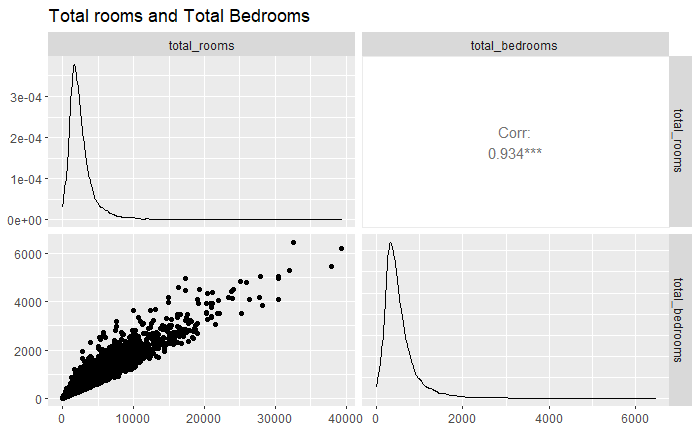

### Discussion

From the output there appears to be a very strong positive relationship between the number of rooms and the total number of bedrooms.

## 3

So, we do find significant correlations. Let’s drop total_bedrooms from the dataset, and use only total_rooms going forward.

```r
housing_prices <-  housing_prices %>%
  select(-total_bedrooms)
```

## 4

We are interested in developing a regression model for the median_house_value of a house in terms of the possible predictor variables in the dataset. Use ggpairs() to investigate correlations between median_house_value and the predictors (this may take a while to run, don’t worry, make coffee or something).

### Thoughts

Using the new data set, complete ggpairs for the entire data set.

### Code

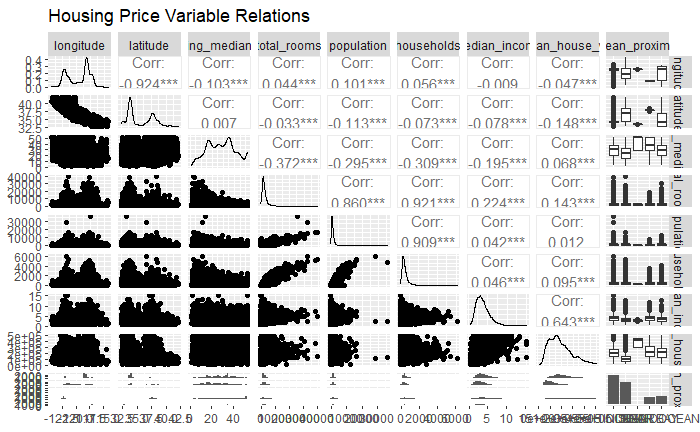

[figure not shown]

```r
pair_plot_all <- ggpairs(housing_prices,
        title = "Housing Price Variable Relations")

print(pair_plot_all, progress = FALSE)
```

## 4ii

Perform further ggplot visualisations of any significant correlations you find.

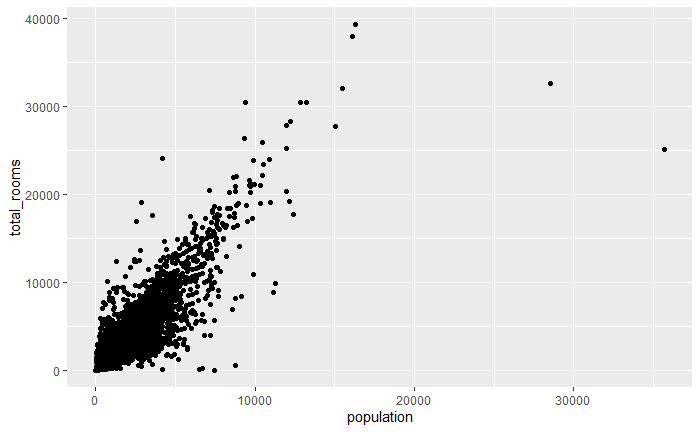

##5 Shortly we may try a regression model to fit the categorical predictor ocean_proximity. Investigate the level of ocean_proximity predictors. How many dummy variables do you expect to get from it?

## Thouhgts

View the categories stored within the ocean proximity variable.

## Code

| ocean_proximity |
| --- |
| NEAR BAY |
| <1H OCEAN |
| INLAND |
| NEAR OCEAN |
| ISLAND |

## Discussion

The number of dummy variables is n-1 and therefore the number which should be created is 4.

## 6

Start with simple linear regression. Regress median_house_value on median_income and check the regression diagnostics.

## Thoughts

Create a linear model with media house value and median income using lm(), then use autoplot to see the results. If acceptable review further information on the model using summary.

## Code

[output not shown]

[output cut: 990 more lines]

```r
model_1
```

```
Call:
lm(formula = median_house_value ~ median_income, data = housing_prices)

Coefficients:
  (Intercept)  median_income
        45457          39987
```

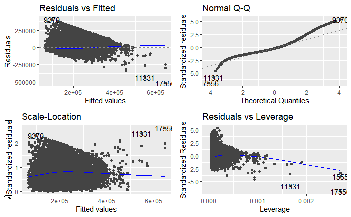

```r
model_1 %>%  summary()
```

```
Call:
lm(formula = median_house_value ~ median_income, data = housing_prices)

Residuals:
    Min      1Q  Median      3Q     Max
-513966  -51564  -13979   36549  403935

Coefficients:
              Estimate Std. Error t value Pr(>|t|)
(Intercept)    45457.0     1359.0   33.45   <2e-16 ***
median_income  39987.0      339.9  117.64   <2e-16 ***
---
Signif. codes:  0 ‘***’ 0.001 ‘**’ 0.01 ‘*’ 0.05 ‘.’ 0.1 ‘ ’ 1

Residual standard error: 74870 on 19673 degrees of freedom
Multiple R-squared:  0.4129,    Adjusted R-squared:  0.4129
F-statistic: 1.384e+04 on 1 and 19673 DF,  p-value: < 2.2e-16
```

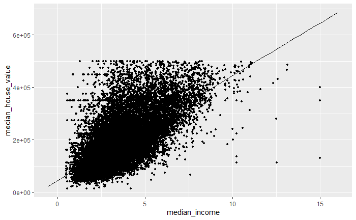

### Discussion

The residuals are scattered around 0 and could be deemed acceptable, however there appears to be a trend in the residuals. The normality of the residuals is poor at the extremities.

The p-value shows effect of income on the house value is statistically significant. The correlation coefficient shows that there is a reasonable positive correlation betweenincome and house value. The value within the model will change the house value by 39987 with 1 unit of income.

## 7

Add another predictor of your choice. Check your assumptions, diagnostics, and interpret the model.

## Code

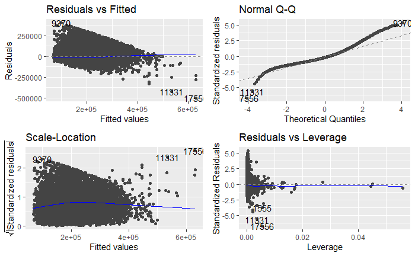

```r
model_2 %>% summary()
```

```
Call:
lm(formula = median_house_value ~ median_income * total_rooms,
    data = housing_prices)

Residuals:
    Min      1Q  Median      3Q     Max
-498488  -51439  -14173   36194  400512

Coefficients:
                            Estimate Std. Error t value Pr(>|t|)
(Intercept)               52245.2308  2098.9825  24.891  < 2e-16 ***
median_income             38405.9386   507.8802  75.620  < 2e-16 ***
total_rooms                  -2.8776     0.7025  -4.097 4.21e-05 ***
median_income:total_rooms     0.6311     0.1461   4.319 1.58e-05 ***
---
Signif. codes:  0 ‘***’ 0.001 ‘**’ 0.01 ‘*’ 0.05 ‘.’ 0.1 ‘ ’ 1

Residual standard error: 74840 on 19671 degrees of freedom
Multiple R-squared:  0.4135,    Adjusted R-squared:  0.4134
F-statistic:  4623 on 3 and 19671 DF,  p-value: < 2.2e-16
```

## Discussion

The diagnostic plots have not changed greatly from the previous model with the exception of the outlier plot in the leverage has been reduced. The normaility still shows to be slightly off of a normal distribution especially on the upper tail. The total room relation to the median income and the house value is statistically significant. The total rooms has a 0.6311 change on the gradient in the previous model and will be steeper. The total rooms will also shift the model down by -3 when all other variables are kept constant.

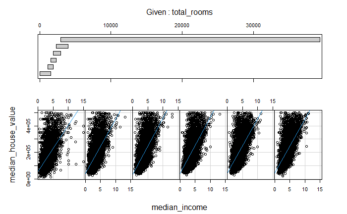

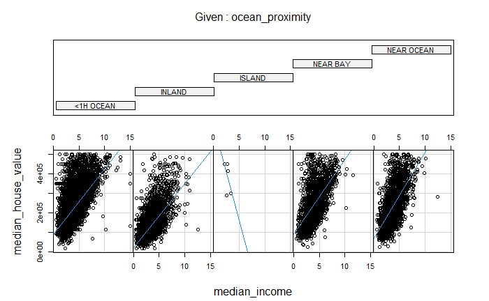